# LEEF2 RRD Ready Check

Author

Uriah Daugaard

Published

March 15, 2024

# Setup

## Dependencies

```r
library(tidyverse)
library(patchwork)
library(LEEF.analysis)
library(lubridate)
library(dplyr)

fn <- "~/git/0.RPackages/LEEF/analysis/LEEF.analysis/inst/LEEF-2/ScriptsByUriah/LEEF2_RRDReadyCheck.qmd"
if (!exists("params")) {
    params <- rmarkdown::yaml_front_matter(fn)$params
}

set.seed(1)
options(dplyr.summarise.inform = FALSE)

options(RRDarrow = params$RRDarrow)
```

## Data

```r
densities <- arrow_read_density() %>%
    arrange(day)

o2 <- arrow_read_o2() %>%
    arrange(day)

water_chem <- arrow_read_toc() %>%
    arrange(day)

conductivity <- arrow_read_conductivity() %>%
    arrange(day)
```

# General remarks

RMK: Flowcytometer is not yet regated, and only included as from the pipeline. Consequently, no data has been cleaned. Only the bimoass is calculated.

# Check 1: are all sampling days present?

## Check 1.1: densities/biomasses present

### All missing

```r
# timestamps and days in RRD
timestamps <- unique(densities$timestamp)
days <- sort(unique(densities$day))

# timestamps and days that should be in RRD
days2 <- sort(c(0 + (0:39 * 7), 2 + (0:39 * 7), 4 + (0:39 * 7)))
timestamps2 <- as_date("20221107", format = "%Y%m%d") + days2
timestamps2 <- gsub("-", "", as.character(timestamps2))

# timestamps and day that should be in RRD but are not
idx <- which(!(days2 %in% days))
missing_days <- days2[idx]
missing_timestamps <- timestamps2[idx]

print("The following Days and timestamps are missing completely in the RRD (if empty none are missing)")
```

```
[1] "The following Days and timestamps are missing completely in the RRD (if empty none are missing)"
```

```r
rbind(
    missing_days = missing_days,
    missing_timestamps = missing_timestamps
)
```

```
missing_days
missing_timestamps
```

### bemovi_mag_16 missing

The timestamps `20230602`, `20230616` and `20230621` are missing because of a dataloss during processing.

```r
msm <- "bemovi_mag_16"
# timestamps and days in RRD |> unique()=
timestamps <- densities |>
    filter(measurement == msm) |>
    select(timestamp) |>
    unlist() |>
    unique()
days <- densities |>
    filter(measurement == msm) |>
    select(day) |>
    unlist() |>
    unique() |>
    sort()

# timestamps and days that should be in RRD
days2 <- sort(c(0 + (0:39 * 7), 2 + (0:39 * 7), 4 + (0:39 * 7)))
timestamps2 <- as_date("20221107", format = "%Y%m%d") + days2
timestamps2 <- gsub("-", "", as.character(timestamps2))

# timestamps and day that should be in RRD but are not
idx <- which(!(days2 %in% days))
missing_days <- days2[idx]
missing_timestamps <- timestamps2[idx]

print("The following Days and timestamps are missing completely in the RRD (if empty none are missing)")
```

```
[1] "The following Days and timestamps are missing completely in the RRD (if empty none are missing)"
```

```r
rbind(
    missing_days = missing_days,
    missing_timestamps = missing_timestamps
)
```

```
missing_days
missing_timestamps
```

### bemovi_mag_25 missing

The timestamps `20230602`, `20230616` and `20230621` are missing because of a dataloss during processing.

```r
msm <- "bemovi_mag_25"
# timestamps and days in RRD |> unique()=
timestamps <- densities |>
    filter(measurement == msm) |>
    select(timestamp) |>
    unlist() |>
    unique()
days <- densities |>
    filter(measurement == msm) |>
    select(day) |>
    unlist() |>
    unique() |>
    sort()

# timestamps and days that should be in RRD
days2 <- sort(c(0 + (0:39 * 7), 2 + (0:39 * 7), 4 + (0:39 * 7)))
timestamps2 <- as_date("20221107", format = "%Y%m%d") + days2
timestamps2 <- gsub("-", "", as.character(timestamps2))

# timestamps and day that should be in RRD but are not
idx <- which(!(days2 %in% days))
missing_days <- days2[idx]
missing_timestamps <- timestamps2[idx]

print("The following Days and timestamps are missing completely in the RRD (if empty none are missing)")
```

```
[1] "The following Days and timestamps are missing completely in the RRD (if empty none are missing)"
```

```r
rbind(
    missing_days = missing_days,
    missing_timestamps = missing_timestamps
)
```

```
missing_days
missing_timestamps
```

### bemovi_mag_25_cropped missing

The timestamps `20230602`, `20230616` and `20230621` are missing because of a dataloss during processing.

```r
msm <- "bemovi_mag_25_cropped"
# timestamps and days in RRD |> unique()=
timestamps <- densities |>
    filter(measurement == msm) |>
    select(timestamp) |>
    unlist() |>
    unique()
days <- densities |>
    filter(measurement == msm) |>
    select(day) |>
    unlist() |>
    unique() |>
    sort()

# timestamps and days that should be in RRD
days2 <- sort(c(0 + (0:39 * 7), 2 + (0:39 * 7), 4 + (0:39 * 7)))
timestamps2 <- as_date("20221107", format = "%Y%m%d") + days2
timestamps2 <- gsub("-", "", as.character(timestamps2))

# timestamps and day that should be in RRD but are not
idx <- which(!(days2 %in% days))
missing_days <- days2[idx]
missing_timestamps <- timestamps2[idx]

print("The following Days and timestamps are missing completely in the RRD (if empty none are missing)")
```

```
[1] "The following Days and timestamps are missing completely in the RRD (if empty none are missing)"
```

```r
rbind(
    missing_days = missing_days,
    missing_timestamps = missing_timestamps
)
```

```
missing_days
missing_timestamps
```

### flowcam missing

```r
msm <- "flowcam"
# timestamps and days in RRD |> unique()=
timestamps <- densities |>
    filter(measurement == msm) |>
    select(timestamp) |>
    unlist() |>
    unique()
days <- densities |>
    filter(measurement == msm) |>
    select(day) |>
    unlist() |>
    unique() |>
    sort()

# timestamps and days that should be in RRD
days2 <- sort(c(0 + (0:39 * 7), 2 + (0:39 * 7), 4 + (0:39 * 7)))
timestamps2 <- as_date("20221107", format = "%Y%m%d") + days2
timestamps2 <- gsub("-", "", as.character(timestamps2))

# timestamps and day that should be in RRD but are not
idx <- which(!(days2 %in% days))
missing_days <- days2[idx]
missing_timestamps <- timestamps2[idx]

print("The following Days and timestamps are missing completely in the RRD (if empty none are missing)")
```

```
[1] "The following Days and timestamps are missing completely in the RRD (if empty none are missing)"
```

```r
rbind(
    missing_days = missing_days,
    missing_timestamps = missing_timestamps
)
```

```
missing_days
missing_timestamps
```

### flowcytometer missing

```r
msm <- "flowcytometer"
# timestamps and days in RRD |> unique()=
timestamps <- densities |>
    filter(measurement == msm) |>
    select(timestamp) |>
    unlist() |>
    unique()
days <- densities |>
    filter(measurement == msm) |>
    select(day) |>
    unlist() |>
    unique() |>
    sort()

# timestamps and days that should be in RRD
days2 <- sort(c(0 + (0:39 * 7), 2 + (0:39 * 7), 4 + (0:39 * 7)))
timestamps2 <- as_date("20221107", format = "%Y%m%d") + days2
timestamps2 <- gsub("-", "", as.character(timestamps2))

# timestamps and day that should be in RRD but are not
idx <- which(!(days2 %in% days))
missing_days <- days2[idx]
missing_timestamps <- timestamps2[idx]

print("The following Days and timestamps are missing completely in the RRD (if empty none are missing)")
```

```
[1] "The following Days and timestamps are missing completely in the RRD (if empty none are missing)"
```

```r
rbind(
    missing_days = missing_days,
    missing_timestamps = missing_timestamps
)
```

```
missing_days
missing_timestamps
```

### manualcount missing

```r
msm <- "manualcount"
# timestamps and days in RRD |> unique()=
timestamps <- densities |>
    filter(measurement == msm) |>
    select(timestamp) |>
    unlist() |>
    unique()
days <- densities |>
    filter(measurement == msm) |>
    select(day) |>
    unlist() |>
    unique() |>
    sort()

# timestamps and days that should be in RRD
days2 <- sort(c(0 + (0:39 * 7), 2 + (0:39 * 7), 4 + (0:39 * 7)))
timestamps2 <- as_date("20221107", format = "%Y%m%d") + days2
timestamps2 <- gsub("-", "", as.character(timestamps2))

# timestamps and day that should be in RRD but are not
idx <- which(!(days2 %in% days))
missing_days <- days2[idx]
missing_timestamps <- timestamps2[idx]

print("The following Days and timestamps are missing completely in the RRD (if empty none are missing)")
```

```
[1] "The following Days and timestamps are missing completely in the RRD (if empty none are missing)"
```

```r
rbind(
    missing_days = missing_days,
    missing_timestamps = missing_timestamps
)
```

```
missing_days
missing_timestamps
```

## Check 1.2: oxygen

```r
# timestamps and days in RRD
timestamps_o2 <- unique(o2$timestamp)
days_o2 <- sort(unique(o2$day))

# timestamps and day that should be in RRD but are not
idx <- which(!(days2 %in% days_o2))
missing_days_o2 <- days2[idx]
missing_timestamps_o2 <- timestamps2[idx]

print("The following Days and timestamps are missing completely in the RRD (if empty none are missing)")
```

```
[1] "The following Days and timestamps are missing completely in the RRD (if empty none are missing)"
```

```r
rbind(
    missing_days = missing_days_o2,
    missing_timestamps = missing_timestamps_o2
)
```

```
missing_days
missing_timestamps
```

## Check 1.3: water chemistry

TODO [ ]: These are not analysed yet due to machine failure.

```r
# timestamps and days in RRD
timestamps_wc <- unique(water_chem$timestamp)
days_wc <- sort(unique(water_chem$day))

# timestamps and day that should be in RRD but are not
idx <- which(!(days2 %in% days_wc))
missing_days_wc <- days2[idx]
missing_timestamps_wc <- timestamps2[idx]

print("The following Days and timestamps are missing completely in the RRD (if empty none are missing)")
```

```
[1] "The following Days and timestamps are missing completely in the RRD (if empty none are missing)"
```

```r
rbind(
    missing_days = missing_days_wc,
    missing_timestamps = missing_timestamps_wc
)
```

```
                   [,1]
missing_days       "252"
missing_timestamps "20230717"
```

Note UD (20230816): there are many missing sampling days for the water chemistry. As I understand it, this data is not yet ready (i.e. not all samples have been processed). It is probably still worth checking whether the non processed ones correspond to the missing sampling days listed here.

## Check 1.4: conductivity

```r
# timestamps and days in RRD
timestamps_con <- unique(conductivity$timestamp)
days_con <- sort(unique(conductivity$day))

# timestamps and day that should be in RRD but are not
idx <- which(!(days2 %in% days_con))
missing_days_con <- days2[idx]
missing_timestamps_con <- timestamps2[idx]

print("The following Days and timestamps are missing completely in the RRD (if empty none are missing)")
```

```
[1] "The following Days and timestamps are missing completely in the RRD (if empty none are missing)"
```

```r
rbind(
    missing_days = missing_days_con,
    missing_timestamps = missing_timestamps_con
)
```

```
missing_days
missing_timestamps
```

# Check 2: are all desired classes present and are no other classes present?

This code chunk simply specifies the classes of interest. Note that I’ve already removed Loxo and Euplotes from the classes of interest, which in “LEEF2_RRD_PostPipelineCleaning.qmd” is done under “Exclusion of time series that are wrong classifications or only noise”.

```r
# these are the desired classes in the respective measurement methods

Bemovi16_classes <- c(
    "Coleps_irchel",
    "Colpidium",
    "Stylonychia2",
    "Paramecium_caudatum",
    "Paramecium_bursaria",
    "Debris_and_other"
)

Bemovi25_classes <- c(
    "Coleps_irchel",
    "Colpidium",
    "Stylonychia2",
    "Paramecium_caudatum",
    "Paramecium_bursaria",
    "Debris_and_other"
)

Bemovi25cropped_classes <- c("Debris_and_other")

Flowcam_classes <- c(
    "Chlamydomonas",
    "Debris",
    "DigestedAlgae",
    "Small_unidentified",
    "DividingChlamydomonas",
    "ChlamydomonasClumpsLarge",
    "ChlamydomonasClumpsSmall",
    "CiliateCysts",
    "CystsWhite",
    "DigestedWhite",
    "Small_cells"
)

Flowcytometer_classes <- c(
    "bacteria",
    "algae"
)

manual_classes <- c("Didinium")
```

## Check 2.1: are all desired classes present?

```r
# now the tests
## bemovi 16
idx <- Bemovi16_classes %in% unique(densities[densities$measurement == "bemovi_mag_16", ]$species)
test <- all(idx)
print(paste("Are all desired classes present in bemovi_mag_16?", test))
```

```
[1] "Are all desired classes present in bemovi_mag_16? TRUE"
```

```r
if (!test) {
    print(paste("The following classes are missing from it:", Bemovi16_classes[idx]))
}

## bemovi 25
idx <- Bemovi25_classes %in% unique(densities[densities$measurement == "bemovi_mag_25", ]$species)
test <- all(idx)
print(paste("Are all desired classes present in bemovi_mag_25?", test))
```

```
[1] "Are all desired classes present in bemovi_mag_25? TRUE"
```

```r
if (!test) {
    print(paste("The following classes are missing from it:", Bemovi25_classes[idx]))
}

## bemovi 25 cropped
idx <- Bemovi25cropped_classes %in% unique(densities[densities$measurement == "bemovi_mag_25_cropped", ]$species)
test <- all(idx)
print(paste("Are all desired classes present in bemovi_mag_25 cropped?", test))
```

```
[1] "Are all desired classes present in bemovi_mag_25 cropped? TRUE"
```

```r
if (!test) {
    print(paste("The following classes are missing from it:", Bemovi25cropped_classes[idx]))
}

## Flowcam
idx <- Flowcam_classes %in% unique(densities[densities$measurement == "flowcam", ]$species)
test <- all(idx)
print(paste("Are all desired classes present in flowcam?", test))
```

```
[1] "Are all desired classes present in flowcam? TRUE"
```

```r
if (!test) {
    print(paste("The following classes are missing from it:", Flowcam_classes[idx]))
}

## Flowcytometer
idx <- Flowcytometer_classes %in% unique(densities[densities$measurement == "flowcytometer", ]$species)
test <- all(idx)
print(paste("Are all desired classes present in Flowcytometer?", test))
```

```
[1] "Are all desired classes present in Flowcytometer? TRUE"
```

```r
if (!test) {
    print(paste("The following classes are missing from it:", Flowcytometer_classes[idx]))
}

print("Is Didinium present?")
```

```
[1] "Is Didinium present?"
```

```r
"Didinium" %in% unique(densities$species)
```

```
[1] TRUE
```

## Check 2.2: are any undesired classes present?

Now the opposite: are any classes present that shouldnt be?

```r
## test 1
classes <- unique(densities$species)
idx <- classes %in% unique(c(Bemovi16_classes, Bemovi25_classes, Bemovi25cropped_classes, Flowcam_classes, Flowcytometer_classes, manual_classes))
print("The following classes are present but shouldn't be:")
```

```
[1] "The following classes are present but shouldn't be:"
```

```r
classes[!idx]
```

```
character(0)
```

```r
densities |>
    filter(species %in% classes[!idx]) |>
    select(species, measurement, timestamp) |>
    distinct()
```

```
# A tibble: 0 × 3
# ℹ 3 variables: species <chr>, measurement <chr>, timestamp <int>
```

```r
## test2
Loxo <- "Loxocephallus" %in% unique(densities[densities$measurement == "flowcam", ]$species)
print("Loxocephalus has been correctly removed from the flowcam")
```

```
[1] "Loxocephalus has been correctly removed from the flowcam"
```

```r
!Loxo
```

```
[1] TRUE
```

```r
## test3
bots <- unique(densities$bottle)
actual_bots <- 1:32
actual_bots <- ifelse(actual_bots < 10, paste0("b_0", actual_bots), paste0("b_", actual_bots))
idx <- bots %in% actual_bots
print("The following bottles are present but shouldn't be:")
```

```
[1] "The following bottles are present but shouldn't be:"
```

```r
bots[!idx]
```

```
character(0)
```

```r
densities |>
    filter(bottle %in% bots[!idx]) |>
    select(bottle, measurement) |>
    distinct()
```

```
# A tibble: 0 × 2
# ℹ 2 variables: bottle <chr>, measurement <chr>
```

# Check 3: do some measurement methods have missing timestamps (that are unexpected)?

## Check 3.1: densities/biomasses

The data.frame “dd_missing_timestamps” should be empty (i.e. have 0 rows)

```r
timestamps2 <- as.numeric(timestamps2)
missing_timestamps2 <- missing_timestamps

dd_missing_timestamps <- densities %>%
    group_by(measurement, species, bottle) %>%
    reframe(missing_timestamps = as.numeric(timestamps2[which(!(timestamps2 %in% unique(timestamp)))])) %>%
    dplyr::filter( # here I filter out things that we know about (please update and document!)
        !(species %in% c("OtherCiliate", "HNA", "LNA", "MNA")), # these things should not be in anyway
        !(species == "Loxocephallus" & measurement == "flowcam"), # these things should not be in anyway
        !(species %in% c("airbubbles", "Cryptomonas")), # these things should not be in anyway
        !(missing_timestamps %in% as.numeric(missing_timestamps2)), # these timestamps are missing completely (see check 1)
        measurement != "manualcount", # didinium was not always measured
        # !(measurement == "flowcytometer" & (missing_timestamps %in% c())) # For the flowcytometer for the following timestamps there was no data collection: c()
    )
# dd_missing_timestamps

print(paste("Number of rows in dd_missing_timestamps:", nrow(dd_missing_timestamps)))
```

```
[1] "Number of rows in dd_missing_timestamps: 0"
```

If it is not empty the next code chunk prints out some information

```r
if (nrow(dd_missing_timestamps) > 0) {
    for (sp in unique(dd_missing_timestamps$species)) {
        d <- dd_missing_timestamps %>%
            dplyr::filter(species == sp)
        print(paste(sp, "has the following missing timestamps (the number indicates in how many bottles it is missing)"))
        print(table(d$missing_timestamps))
    }
}
```

UD comment (20230816):

RMK: In the whole of flowcam is no 0 density. I assumed, that these missing were 0 but not added as zero. I fixed this.

**On 20230315 some flowcytometry samples have only 2 replicates instead of 3 replicates. On all other dates there should be 3 replicates.**

## Check 3.2: oxygen

The following data.frame should be empty RMK

[output not shown]

```r
dd_missing_timestamps_o2 <- o2 %>%
    group_by(sensor, bottle) %>%
    reframe(missing_timestamps = as.numeric(timestamps2[which(!(timestamps2 %in% unique(timestamp)))])) %>%
    dplyr::filter( # Previously confirmed missing data is filtered out
        !(missing_timestamps %in% as.numeric(missing_timestamps_o2)), # these timestamps are missing completely (see check 1)
    )

dd_missing_timestamps_o2
```

```
# A tibble: 0 × 3
# ℹ 3 variables: sensor <int>, bottle <chr>, missing_timestamps <dbl>
```

## Check 3.3: water chemistry

The following data.frame should be empty

```r
dd_missing_timestamps_wc <- water_chem %>%
    group_by(type, bottle) %>%
    reframe(missing_timestamps = as.numeric(timestamps2[which(!(timestamps2 %in% unique(timestamp)))])) %>%
    dplyr::filter( # Previously confirmed missing data is filtered out
        !(missing_timestamps %in% as.numeric(missing_timestamps_wc)), # these timestamps are missing completely (see check 1)
    )

dd_missing_timestamps_wc
```

```
# A tibble: 38 × 3
   type  bottle missing_timestamps
   <chr> <chr>               <dbl>
 1 IC    b_06             20221107
 2 IC    b_26             20230503
 3 IC    b_26             20230522
 4 IC    b_27             20230503
 5 IC    b_28             20230503
 6 IC    b_29             20230503
 7 IC    b_29             20230626
 8 IC    b_30             20230503
 9 IC    b_31             20230503
10 IC    b_32             20230503
# ℹ 28 more rows
```

## Check 3.4: conductivity

The following data.frame should be empty

```r
dd_missing_timestamps_con <- conductivity %>%
    group_by(bottle) %>%
    reframe(missing_timestamps = as.numeric(timestamps2[which(!(timestamps2 %in% unique(timestamp)))])) %>%
    dplyr::filter( # Previously confirmed missing data is filtered out
        !(missing_timestamps %in% as.numeric(missing_timestamps_con)), # these timestamps are missing completely (see check 1)
    )

dd_missing_timestamps_con
```

```
# A tibble: 0 × 2
# ℹ 2 variables: bottle <chr>, missing_timestamps <dbl>
```

# Check 4: are there any NAs in the data that are not accounted for or expected?

## Check 4.1: densities/biomasses

The following data.frame should be empty

```r
NAs <- densities %>%
    dplyr::filter(
        !(species == "Loxocephallus" & measurement == "flowcam"), # should not be in anyway
        !(species %in% c(
            "LNA", "MNA", "HNA", "Debris", "DigestedAlgae", "Cryptomonas",
            "Small_unidentified", "Didinium", "algae", "OtherCiliate",
            "Debris_and_other", "CiliateCysts", "CystsWhite", "airbubbles",
            "DigestedWhite"
        )), # biomass not calculated for these classes
    ) %>%
    group_by(measurement, species, bottle, timestamp) %>%
    summarize(
        densityNA = sum(is.na(density)),
        biomassNA = sum(is.na(biomass))
    ) %>%
    dplyr::filter(biomassNA > 0 | densityNA > 0)
NAs
```

```
# A tibble: 971 × 6
# Groups:   measurement, species, bottle [331]
   measurement   species       bottle timestamp densityNA biomassNA
   <chr>         <chr>         <chr>      <int>     <int>     <int>
 1 bemovi_mag_16 Coleps_irchel b_01    20230602         1         1
 2 bemovi_mag_16 Coleps_irchel b_01    20230616         1         1
 3 bemovi_mag_16 Coleps_irchel b_01    20230621         1         1
 4 bemovi_mag_16 Coleps_irchel b_02    20230602         1         1
 5 bemovi_mag_16 Coleps_irchel b_02    20230616         1         1
 6 bemovi_mag_16 Coleps_irchel b_02    20230621         1         1
 7 bemovi_mag_16 Coleps_irchel b_03    20230602         1         1
 8 bemovi_mag_16 Coleps_irchel b_03    20230616         1         1
 9 bemovi_mag_16 Coleps_irchel b_03    20230621         1         1
10 bemovi_mag_16 Coleps_irchel b_04    20230602         1         1
# ℹ 961 more rows
```

## Check 4.2: oxygen

The following data.frame should be empty

```r
NAs_o2 <- o2 %>%
    group_by(sensor, bottle) %>%
    summarize(o2NA = sum(is.na(percent_o2))) %>%
    dplyr::filter(o2NA > 0)
NAs_o2
```

```
# A tibble: 3 × 3
# Groups:   sensor [2]
  sensor bottle  o2NA
   <int> <chr>  <int>
1      4 b_08       1
2      4 b_10       1
3      9 b_29       1
```

## Check 4.3: water chemistry

TODO [ ]: Needs to be checked

The following data.frame should be empty

```r
NAs_wc <- water_chem %>%
    group_by(type, bottle, timestamp) %>%
    summarize(concentrationNA = sum(is.na(concentration))) %>%
    dplyr::filter(concentrationNA > 0)
NAs_wc
```

```
# A tibble: 0 × 4
# Groups:   type, bottle [0]
# ℹ 4 variables: type <chr>, bottle <chr>, timestamp <int>,
#   concentrationNA <int>
```

## Check 4.4: conductivity

The following data.frame should be empty

```r
NAs_con <- conductivity %>%
    group_by(bottle) %>%
    summarize(conductivityNA = sum(is.na(conductivity))) %>%
    dplyr::filter(conductivityNA > 0)
NAs_con
```

```
# A tibble: 0 × 2
# ℹ 2 variables: bottle <chr>, conductivityNA <int>
```

# Check 5: have the faulty videos been correctly excluded and the densities correctly recalculated?

RMK: Videos identified as moviong frame below are added to the list of videos to be removed. The list is then used to remove the videos from the RRD. The densities are then recalculated.

This part is here to check whether the faulty videos (e.g. moving background) have correctly been removed and that the densities have correctly been recalculated.

The first code chunk simply loads in the information about which videos are faulty.

```r
# read in video file names to remove
tocheck_1stmethod <- read_csv("VideoChecks/FirstMethodCheck/tocheck_1stmethod.csv")
tocheck_2ndmethod <- read_csv("VideoChecks/SecondMethodCheck/tocheck_2ndmethod.csv")
tocheck_3rdmethod16 <- read_csv("VideoChecks/ThirdMethodCheck/videos_16x.csv")
tocheck_3rdmethod25 <- read_csv("VideoChecks/ThirdMethodCheck/videos_25x.csv")

# 16x
videos_to_remove_16 <- tocheck_3rdmethod16 %>%
    dplyr::filter(decision != "ok") %>%
    mutate(
        video.nr = as.numeric(sub(".+_(.+)", "\\1", file)),
        bottle = ceiling((video.nr - 100) / 3),
        bottle = ifelse(bottle < 10, paste0("b_0", bottle), paste0("b_", bottle))
    )

# 25x
videos_to_remove_25_1 <- tocheck_1stmethod %>%
    dplyr::filter(decision != "ok")
videos_to_remove_25_2 <- tocheck_2ndmethod %>%
    dplyr::filter(decision != "ok")
videos_to_remove_25_3 <- tocheck_3rdmethod25 %>%
    dplyr::filter(decision != "ok")

videos_to_remove_25 <- full_join(
    videos_to_remove_25_1,
    full_join(videos_to_remove_25_2, videos_to_remove_25_3)
) %>%
    distinct() %>%
    mutate(
        video.nr = as.numeric(sub(".+_(.+)", "\\1", file)),
        bottle = ceiling(video.nr / 3),
        bottle = ifelse(bottle < 10, paste0("b_0", bottle), paste0("b_", bottle))
    )
```

## Check 5.1: have the faulty videos been excluded?

The following data.frame should be empty (i.e. 0 rows)

```r
video16 <- arrow_read_table("bemovi_16_morph") %>%
    collect() %>%
    dplyr::filter(file %in% videos_to_remove_16$file)

nrow(video16)
```

```
[1] 0
```

The following data.frame should be empty (i.e. 0 rows)

```r
video25 <- arrow_read_table("bemovi_25_morph") %>%
    collect() %>%
    dplyr::filter(file %in% videos_to_remove_25$file)

nrow(video25)
```

```
[1] 0
```

The following data.frame should be empty (i.e. 0 rows)

```r
video25_cropped <- arrow_read_table("bemovi_25_morph_cropped") %>%
    collect() %>%
    dplyr::filter(file %in% videos_to_remove_25$file)

nrow(video25_cropped)
```

```
[1] 0
```

If any of them are not empty then the videos have not been removed (completely).

## Check 5.2: have the densities been correctly recalculated?

TODO [ ]: Check what and why

The file “new_densities.csv” contains the densities of the species that I’ve locally calculated after excluding the videos. I therefore compare these densities to the ones that are in the RRD.

**Note UD (20230816)**: if the check fails it might also be because the “new_densities.csv” is no longer up-to-date. This file is produced in the script “LEEF2_RRD_PostPipelineCleaning.qmd”. If in the mean time the RRD has been rerun (for instance because of new classifiers), then “new_densities.csv” also needs to be remade, otherwise this check might wrongly fail…

```r
new_densities <- read_csv("VideoChecks/new_densities_for_doublecheck.csv")
new_densities <- new_densities %>%
    dplyr::filter(!(bottle %in% c("b_02", "b_15", "b_20", "b_31"))) %>%
    mutate(new_densities = density) %>%
    select(-density)

compare_densities <- left_join(
    new_densities %>% dplyr::filter(species != "Loxocephallus", species != "Euplotes"),
    densities
)

print("Do the densities in the RRD correspond to the densities in new_densities.csv")
```

```
[1] "Do the densities in the RRD correspond to the densities in new_densities.csv"
```

```r
all(round(compare_densities$density, 3) == round(compare_densities$new_densities, 3))
```

```
[1] FALSE
```

```r
compare_densities |>
    mutate(identical = round(density, 3) == round(new_densities, 3)) |>
    filter(!identical)
```

```
# A tibble: 11 × 14
   timestamp bottle species      measurement new_densities   day density biomass
       <dbl> <chr>  <chr>        <chr>               <dbl> <int>   <dbl>   <dbl>
 1  20230512 b_29   Debris_and_… bemovi_mag…         11.7    186   11.7       NA
 2  20221209 b_32   Debris_and_… bemovi_mag…        105.      32   52.3       NA
 3  20230327 b_22   Debris_and_… bemovi_mag…          8.97   140    4.49      NA
 4  20230417 b_23   Debris_and_… bemovi_mag…         19.4    161    9.72      NA
 5  20230517 b_19   Debris_and_… bemovi_mag…         34.4    191   17.2       NA
 6  20230526 b_22   Debris_and_… bemovi_mag…          5.98   200    2.99      NA
 7  20230526 b_27   Debris_and_… bemovi_mag…          6.73   200    3.36      NA
 8  20230609 b_05   Debris_and_… bemovi_mag…         38.1    214   19.1       NA
 9  20230719 b_10   Debris_and_… bemovi_mag…         43.4    254   21.7       NA
10  20230721 b_17   Debris_and_… bemovi_mag…         12.0    256    5.98      NA
11  20230807 b_22   Debris_and_… bemovi_mag…          6.73   273    3.36      NA
# ℹ 6 more variables: incubator <chr>, temperature <chr>, resources <chr>,
#   salinity <chr>, replicate <int>, identical <lgl>
```

# Check 6: has the density and the biomass been set to 0 for species that have not been found?

**Note UD (20230816):** I’m currently not sure how to test this, because if a species is not present in a certain bottle on a certain sampling day, is it because it wasn’t tracked/detected and the code failed to put the density to 0, or is it because the raw data is either missing or has not been processes? See also my comment under Check 3.1 above. @Rainer: I think it’s easier to check for this once all tests above pass. So please once the tests pass have a look and double check that this code is working.

Essentially, in the pipeline there is code that sets the density of a class (i.e. the species_tracked in the .yml) to 0 if for the currently processed sampling day it was not detected in a bottle. E.g. for the flowcam I think it is done here:https://github.com/LEEF-UZH/LEEF.measurement.flowcam/blob/LEEF-2/R/classify_LEEF_2.R, line 115 onwwards. It is this working? (same goes for the video script).

# Check 7: have the density and trait data of Colpidium and P. caudatum been corrected manually?

This part is here to check whether the wrong classificaiton of P.caudatum as Colpidium has been manually corrected and the densities recalculated

## Check 7.1: Has the classification been corrected manually?

The following data.frame should be empty (i.e. 0 rows)

```r
morph16 <- arrow_read_table("bemovi_16_morph") %>%
    collect() %>%
    dplyr::filter(
        bottle %in% c("b_02", "b_15", "b_20", "b_31"),
        timestamp >= 20230403,
        species == "Colpidium"
    )

nrow(morph16)
```

```
[1] 0
```

The following data.frame should be empty (i.e. 0 rows)

```r
morph25 <- arrow_read_table("bemovi_25_morph") %>%
    collect() %>%
    dplyr::filter(
        bottle %in% c("b_02", "b_15", "b_20", "b_31"),
        timestamp >= 20230403,
        species == "Colpidium"
    )

nrow(morph25)
```

```
[1] 0
```

If any of them are not empty then the classificaiton has not been corrected manually.

## Check 7.2: have the densities been correctly recalculated?

The file “new_PCaudatum_densities_for_doublecheck.csv” contains the densities of the species that I’ve locally calculated after correcting the classification. I therefore compare these densities to the ones that are in the RRD.

**Note UD (20230817)**: if the check fails it might also be because the “new_PCaudatum_densities_for_doublecheck.csv” is no longer up-to-date. This file is produced in the script “LEEF2_RRD_PostPipelineCleaning.qmd”. If in the mean time the RRD has been rerun (for instance because of new classifiers), then “new_PCaudatum_densities_for_doublecheck.csv” also needs to be remade, otherwise this check might wrongly fail…

```r
new_PCaudatum_densities <- read_csv("new_PCaudatum_densities_for_doublecheck.csv")
new_PCaudatum_densities <- new_PCaudatum_densities %>%
    mutate(new_densities = density) %>%
    select(-density)

compare_densities2 <- left_join(
    new_PCaudatum_densities %>% dplyr::filter(species != "Loxocephallus", species != "Euplotes"),
    densities
)

print("Do the densities in the RRD correspond to the densities in new_PCaudatum_densities.csv")
```

```
[1] "Do the densities in the RRD correspond to the densities in new_PCaudatum_densities.csv"
```

```r
all(round(compare_densities2$density, 3) == round(compare_densities2$new_densities, 3))
```

```
[1] TRUE
```

```r
compare_densities2 |>
    mutate(identical = round(density, 3) == round(new_densities, 3)) |>
    filter(!identical) |>
    select(c(1:5, 7))
```

```
# A tibble: 0 × 6
# ℹ 6 variables: timestamp <dbl>, bottle <chr>, species <chr>,
#   measurement <chr>, new_densities <dbl>, density <dbl>
```

# Check 8: has the biomass of the species been correctly implemented?

TODO [ ]: Check what and why

The file “biomass20221107_doubleCheck.csv” contains the biomasses of the species that I calculated. I therefore compare these densities to the ones that are in the RRD. Note that this only checks the flowcam and the video biomasses, not the flowcytometer (bacteria) ones.

**Note UD (20230817)**: if the check fails it might also be because the “biomass20221107_doubleCheck.csv” is no longer up-to-date. This file is produced in the script “LEEF2_RRD_PostPipelineCleaning.qmd”. If in the mean time the RRD has been rerun (for instance because of new classifiers), then “biomass20221107_doubleCheck.csv” also needs to be remade, otherwise this check might wrongly fail…

```r
new_biomass20221107 <- read_csv("biomass20221107_doubleCheck.csv")
new_biomass20221107 <- new_biomass20221107 %>%
    mutate(new_biomass = biomass) %>%
    select(-biomass)

compare_densities3 <- left_join(
    new_biomass20221107,
    densities,
    join_by(timestamp, day, bottle, species, density, measurement, incubator, temperature, resources, salinity, replicate)
)


print("Do the biomasses in the RRD correspond to the densities in biomass20221107_doubleCheck.csv")
```

```
[1] "Do the biomasses in the RRD correspond to the densities in biomass20221107_doubleCheck.csv"
```

```r
compare_densities3 |>
    mutate(identical = round(biomass, 3) == round(new_biomass, 3)) |>
    filter(!identical) |>
    select(c(1:6, 13:15))
```

```
# A tibble: 0 × 9
# ℹ 9 variables: timestamp <dbl>, day <dbl>, bottle <chr>, species <chr>,
#   density <dbl>, measurement <chr>, new_biomass <dbl>, biomass <dbl>,
#   identical <lgl>
```

# Check 9: has the trend in the water chemistry been removed?

This is a visual test. The read line (the data) and the black line (the intercept) should be the same (minus a small change in intercept, but the slope should be the same). If unsure compare also with the corresponding figure in the document “LEEF2_RRD_PostPipelineCleaning.qmd”.

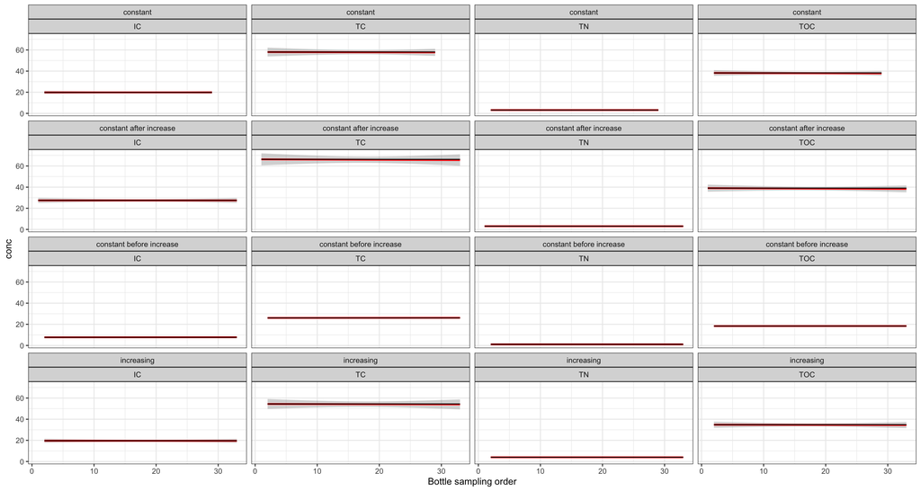

```r
toc <- arrow_read_table("toc") %>%
    collect() %>%
    left_join(arrow_read_table("experimental_design") %>% collect()) %>%
    filter(!is.na(conc))

toc$day <- as.Date(as.character(toc$timestamp), "%Y%m%d") - min(as.Date(as.character(toc$timestamp), "%Y%m%d"))
toc$day <- as.numeric(toc$day)

toc <- toc %>%
    dplyr::mutate(experiment_phase = case_when(
        temperature == "constant" ~ "constant",
        day < 70 ~ "constant before increase",
        day >= 70 & day < 154 ~ "increasing",
        day >= 154 ~ "constant after increase"
    )) %>%
    arrange(timestamp)

toc_sum <- toc %>%
    group_by(experiment_phase, inj_type) %>%
    summarize(intercept = coef(lm(conc ~ position))[1])

position_sum <- toc %>%
    group_by(experiment_phase, inj_type, position) %>%
    summarize(dummy = n())

toc_sum <- full_join(toc_sum, position_sum)

toc %>%
    ggplot(aes(position, conc)) +
    facet_wrap(experiment_phase ~ inj_type) +
    geom_smooth(col = "red", method = "lm") +
    geom_line(data = toc_sum, aes(position, intercept)) +
    labs(x = "Bottle sampling order") +
    theme_bw()
```

# Check add missing data points

## flowcam 20230719 b_01

```r
#|

cat("\n\nWrong number of datapoints:\n")
```

```
Wrong number of datapoints:
```

```r
arrow_read_table(table = "flowcam_density") |>
    group_by(timestamp, bottle) |>
    summarise(n = n()) |>
    filter(n != 11) |>
    collect() |>
    knitr::kable()
```

| timestamp | bottle | n |
| --- | --- | --- |

```r
ts <- arrow_read_table(table = "flowcam_density") |>
    select(timestamp) |>
    distinct() |>
    collect() |>
    unlist() |>
    sort() |>
    as.vector()

cat("\n\nMissing timestamps:\n")
```

```
Missing timestamps:
```

```r
timestamps2[!(timestamps2 %in% ts)]
```

```
numeric(0)
```

## bemovi_mag_16 20230602 20230616 20230621

```r
#|

cat("\n\nWrong number of datapoints:\n")
```

```
Wrong number of datapoints:
```

```r
arrow_read_table(table = "bemovi_16_density") |>
    group_by(timestamp, bottle) |>
    summarise(n = n()) |>
    filter(n != 6) |>
    collect() |>
    knitr::kable()
```

| timestamp | bottle | n |
| --- | --- | --- |

```r
ts <- arrow_read_table(table = "bemovi_16_density") |>
    select(timestamp) |>
    distinct() |>
    collect() |>
    unlist() |>
    sort() |>
    as.vector()

cat("\n\nMissing timestamps:\n")
```

```
Missing timestamps:
```

```r
timestamps2[!(timestamps2 %in% ts)]
```

```
numeric(0)
```

## bemovi_mag_25_cropped 20230602 20230616 20230621

```r
#|

cat("\n\nWrong number of datapoints:\n")
```

```
Wrong number of datapoints:
```

```r
arrow_read_table(table = "bemovi_25_density_cropped") |>
    group_by(timestamp, bottle) |>
    summarise(n = n()) |>
    filter(n != 1) |>
    collect() |>
    knitr::kable()
```

| timestamp | bottle | n |
| --- | --- | --- |

```r
ts <- arrow_read_table(table = "bemovi_25_density_cropped") |>
    select(timestamp) |>
    distinct() |>
    collect() |>
    unlist() |>
    sort() |>
    as.vector()

cat("\n\nMissing timestamps:\n")
```

```
Missing timestamps:
```

```r
timestamps2[!(timestamps2 %in% ts)]
```

```
numeric(0)
```

## bemovi_mag_25 20230602 20230616 20230621

```r
#|

cat("\n\nWrong number of datapoints:\n")
```

```
Wrong number of datapoints:
```

```r
arrow_read_table(table = "bemovi_25_density") |>
    group_by(timestamp, bottle) |>
    summarise(n = n()) |>
    filter(n != 6) |>
    collect() |>
    knitr::kable()
```

| timestamp | bottle | n |
| --- | --- | --- |

```r
ts <- arrow_read_table(table = "bemovi_25_density") |>
    select(timestamp) |>
    distinct() |>
    collect() |>
    unlist() |>
    sort() |>
    as.vector()

cat("\n\nMissing timestamps:\n")
```

```
Missing timestamps:
```

```r
timestamps2[!(timestamps2 %in% ts)]
```

```
numeric(0)
```

## manualcount for all not measured data points

```r
#|

cat("\n\nWrong number of datapoints:\n")
```

```
Wrong number of datapoints:
```

```r
arrow_read_table(table = "manualcount") |>
    group_by(timestamp, bottle) |>
    summarise(n = n()) |>
    filter(n != 1) |>
    collect() |>
    knitr::kable()
```

| timestamp | bottle | n |
| --- | --- | --- |

```r
ts <- arrow_read_table(table = "manualcount") |>
    select(timestamp) |>
    distinct() |>
    collect() |>
    unlist() |>
    sort() |>
    as.vector()

cat("\n\nMissing timestamps:\n")
```

```
Missing timestamps:
```

```r
timestamps2[!(timestamps2 %in% ts)]
```

```
numeric(0)
```

## Conductivity OK

```r
#|

cat("\n\nWrong number of datapoints:\n")
```

```
Wrong number of datapoints:
```

```r
arrow_read_table(table = "conductivity") |>
    group_by(timestamp, bottle) |>
    summarise(n = n()) |>
    filter(n != 1) |>
    collect() |>
    knitr::kable()
```

| timestamp | bottle | n |
| --- | --- | --- |

```r
ts <- arrow_read_table(table = "conductivity") |>
    select(timestamp) |>
    distinct() |>
    collect() |>
    unlist() |>
    sort() |>
    as.vector()

cat("\n\nMissing timestamps:\n")
```

```
Missing timestamps:
```

```r
timestamps2[!(timestamps2 %in% ts)]
```

```
numeric(0)
```

## O2 **missing (n < 2) or to many** (n > 2) datapoints

```r
#|

cat("\n\nWrong number of datapoints:\n")
```

```
Wrong number of datapoints:
```

```r
arrow_read_o2() |>
    group_by(timestamp, bottle) |>
    summarise(n = n(), sensors = paste(sensor |> sort(), collapse = ", ")) |>
    filter(n != 2) |>
    knitr::kable()
```

| timestamp | bottle | n | sensors |
| --- | --- | --- | --- |

```r
ts <- arrow_read_o2() |>
    select(timestamp) |>
    distinct() |>
    unlist() |>
    sort() |>
    as.vector()

cat("\n\nMissing timestamps:\n")
```

```
Missing timestamps:
```

```r
timestamps2[!(timestamps2 %in% ts)]
```

```
numeric(0)
```

## Check TOC missing datapoints

```r
#|

cat("\n\nWrong number of datapoints:\n")
```

```
Wrong number of datapoints:
```

```r
arrow_read_toc() |>
    group_by(timestamp, bottle) |>
    summarise(n = n(), type = paste(type |> sort(), collapse = ", ")) |>
    filter(n != 4) |>
    knitr::kable()
```

| timestamp | bottle | n | type |
| --- | --- | --- | --- |
| 20221107 | b_06 | 2 | TC, TN |

```r
ts <- arrow_read_toc() |>
    select(timestamp) |>
    distinct() |>
    unlist() |>
    sort() |>
    as.vector()

cat("\n\nMissing timestamps:\n")
```

```
Missing timestamps:
```

```r
timestamps2[!(timestamps2 %in% ts)]
```

```
[1] 20230717
```

# Check

TODO Check that salinity etc has been set everywhere, particularly where density is 0!